# 2020 Election Analysis 131 project

Natasha Zhang

## Data

We will essentially start the anlaysis with two data sets. The first one is the election data, which is drawn from here. The data contains county-level election results. Note that this is not the final election results, as recounting are still taking place in many states.

The second dataset is the 2017 United States county-level census data, which is available here.

The following code load in these two data sets: election.raw and census.

```r
## read data and convert candidate names and party names from string to factor
election.raw <- read_csv("candidates_county.csv", col_names = TRUE) %>%
  mutate(candidate = as.factor(candidate), party = as.factor(party))

## remove the word "County" from the county names
words.to.remove = c("County")
remove.words <- function(str, words.to.remove){
  sapply(str, function(str){
    x <- unlist(strsplit(str, " "))
    x <- x[!x %in% words.to.remove]
    return(paste(x, collapse = " "))
  }, simplify = "array", USE.NAMES = FALSE)
}
election.raw$county <- remove.words(election.raw$county, words.to.remove)

## read census data
census <- read_csv("census_county.csv")
```

## *Election data*

1. **Report the dimension of election.raw. Are there missing values in the data set? Compute the total number of distinct values in state in election.raw to verify that the data contains all states and a federal district.**

```
## [1] 31167     5
```

The dimension of election.raw is 31167 rows and 5 columns.

```
## [1] 0
```

No missing values in the election.raw.

```
## [1] 51
```

The data contains all states the Washington D.C.

## *Census data*

**2. Report the dimension of census. Are there missing values in the data set? Compute the total number of distinct values in county in census. Compare the values of total number of distinct county in census with that in election.raw. Comment on your findings.**

```
## [1] 3220   37
```

The census has 3220 rows and 37 columns.

```
## [1] 1
```

1 missing value.

```
## [1] 2825
```

```
## [1] 1955
```

## *Data wrangling*

**3. Construct aggregated data sets from election.raw data: i.e.,**

- Keep the county-level data as it is in *election.raw.*
- Create a state-level summary into a *election.state.*
- Create a federal-level summary into a *election.total.*

**4. How many named presidential candidates were there in the 2020 election? Draw a bar chart of all votes received by each candidate. You can split this into multiple plots or may prefer to plot the results on a log scale. Either way, the results should be clear and legible!**

```
## [1] 38
```

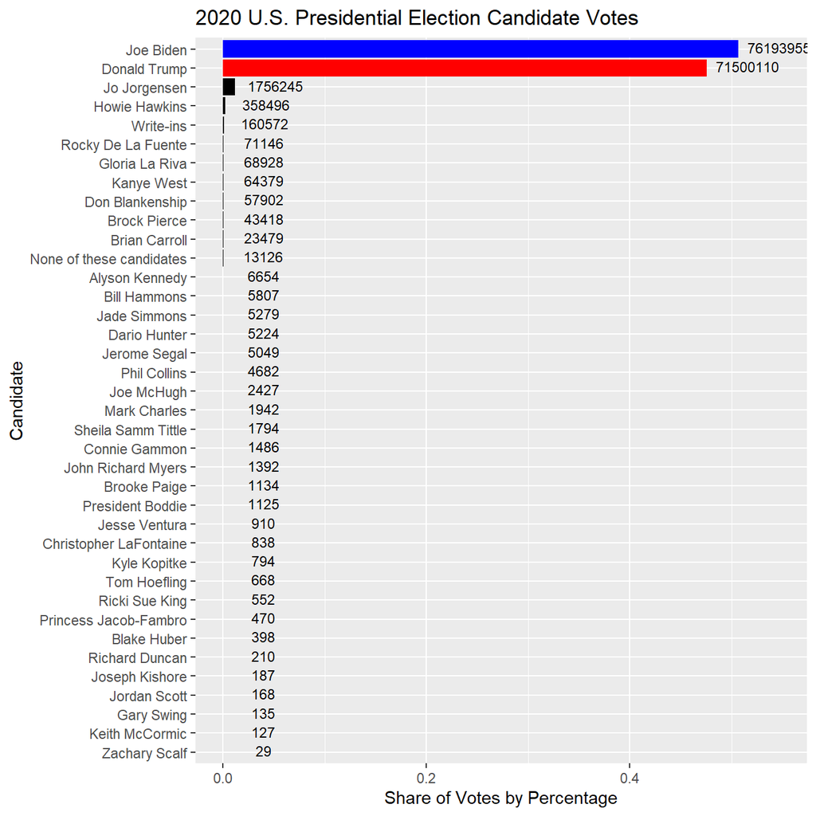

**5. Create data sets county.winner and state.winner by taking the candidate with the highest proportion of votes in both county level and state level. Hint: to create county.winner, start with election.raw, group by county, compute total votes, and pct = votes/total as the proportion of votes. Then choose the highest row using top_n (variable state.winner is similar).**